# Practical machine learning Project

Hans Gommers

2019-01-23

## Background

Using devices such as Jawbone Up, Nike FuelBand, and Fitbit it is now possible to collect a large amount of data about personal activity relatively inexpensively. These type of devices are part of the quantified self movement a group of enthusiasts who take measurements about themselves regularly to improve their health, to find patterns in their behavior, or because they are tech geeks. One thing that people regularly do is quantify how much of a particular activity they do, but they rarely quantify how well they do it. In this project, your goal will be to use data from accelerometers on the belt, forearm, arm, and dumbell of 6 participants. They were asked to perform barbell lifts correctly and incorrectly in 5 different ways. More information is available from the website here: http://groupware.les.inf.puc-rio.br/har (see the section on the Weight Lifting Exercise Dataset).

## Purpose

The goal of this project is to construct a prediction model to classify the manner in which they did the exercise. This is the classe variable. Every other variable may be used for this model.

## Fetching the data

```r
training.data <- read.csv("https://d396qusza40orc.cloudfront.net/predmachlearn/pml-training.csv", header = TRUE, na.strings = c("", "NA"))
testing.data <- read.csv("https://d396qusza40orc.cloudfront.net/predmachlearn/pml-testing.csv", header = TRUE, na.strings = c("", "NA"))
```

## Cleaning the data

1. remove variables which includes to many NA values
2. remove variables which does not contain activity related data and should not be used in any prediction model
3. remove for the test set the same columns as in training set if exist and keep the problem id

```r
training.data <- subset(training.data, select=-c(X,user_name,raw_timestamp_part_1,raw_timestamp_part_2,cvtd_timestamp,new_window,num_window))
testing.data <- subset(testing.data, select=-c(X,user_name,raw_timestamp_part_1,raw_timestamp_part_2,cvtd_timestamp,new_window,num_window))

non.na.vars <- names(training.data[,colSums(is.na(training.data))==0])
training.data <- subset(training.data[,non.na.vars])

testing.data <- subset(testing.data, select=names(testing.data) %in% c(non.na.vars, "problem_id"))
```

## splitting the trainings data in training set and test set

```r
set.seed(98765)
inTrain <- createDataPartition(training.data$classe, p=0.7, list=FALSE)
train.set <- training.data[inTrain,]
test.set <- training.data[-inTrain,]
```

# Prediction models

Three models will be tested 1. rpart model 2. gradient model 3. random forest model

## rpart

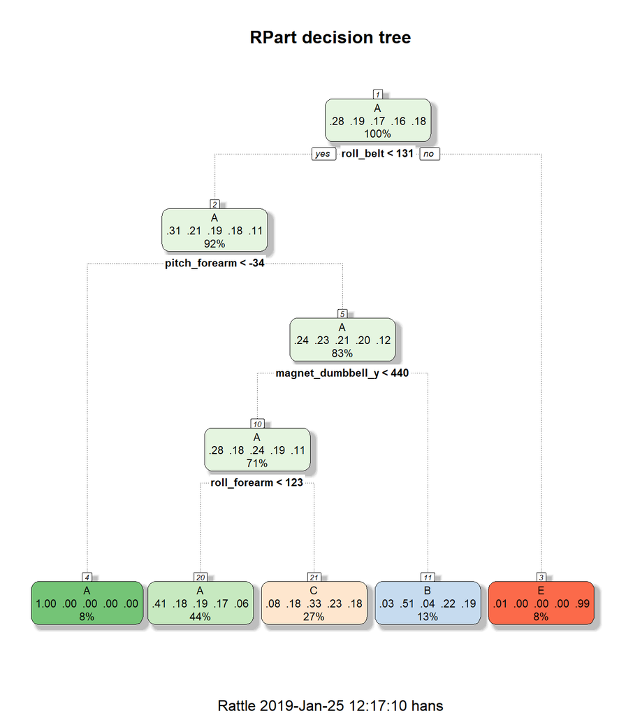

```r
rpart.model <- train(classe ~ ., data=train.set, method="rpart")
rpart.prediction <- predict(rpart.model, newdata = test.set)
fancyRpartPlot(rpart.model$finalModel, main="RPart decision tree")
```

```r
confusionMatrix(test.set$classe, rpart.prediction)
```

```
## Confusion Matrix and Statistics
##
##           Reference
## Prediction    A    B    C    D    E
##          A 1505   25  137    0    7
##          B  462  386  291    0    0
##          C  466   32  528    0    0
##          D  424  177  363    0    0
##          E  156  149  292    0  485
##
## Overall Statistics
##
##                Accuracy : 0.4935
##                  95% CI : (0.4806, 0.5063)
##     No Information Rate : 0.512
##     P-Value [Acc > NIR] : 0.9978
##
##                   Kappa : 0.3387
##  Mcnemar's Test P-Value : NA
##
## Statistics by Class:
##
##                      Class: A Class: B Class: C Class: D Class: E
## Sensitivity            0.4995  0.50195  0.32775       NA  0.98577
## Specificity            0.9412  0.85281  0.88348   0.8362  0.88930
## Pos Pred Value         0.8990  0.33889  0.51462       NA  0.44824
## Neg Pred Value         0.6419  0.91930  0.77711       NA  0.99854
## Prevalence             0.5120  0.13067  0.27375   0.0000  0.08360
## Detection Rate         0.2557  0.06559  0.08972   0.0000  0.08241
## Detection Prevalence   0.2845  0.19354  0.17434   0.1638  0.18386
## Balanced Accuracy      0.7203  0.67738  0.60561       NA  0.93754
```

Result: The accurancy is +/- 50%

## gradient

```r
clusters <- makeCluster(detectCores())
registerDoParallel(clusters)
gbm.model <- train(classe ~ ., data=train.set, method="gbm")
gbm.prediction <- predict(gbm.model, newdata = test.set)
stopCluster(clusters)
confusionMatrix(test.set$classe, gbm.prediction)
```

```
## Confusion Matrix and Statistics
##
##           Reference
## Prediction    A    B    C    D    E
##          A 1637   28    5    3    1
##          B   30 1075   31    3    0
##          C    0   32  983    7    4
##          D    1    2   22  930    9
##          E    3   16    7   18 1038
##
## Overall Statistics
##
##                Accuracy : 0.9623
##                  95% CI : (0.9571, 0.967)
##     No Information Rate : 0.2839
##     P-Value [Acc > NIR] : < 2.2e-16
##
##                   Kappa : 0.9523
##  Mcnemar's Test P-Value : 0.0001318
##
## Statistics by Class:
##
##                      Class: A Class: B Class: C Class: D Class: E
## Sensitivity            0.9797   0.9324   0.9380   0.9677   0.9867
## Specificity            0.9912   0.9865   0.9911   0.9931   0.9909
## Pos Pred Value         0.9779   0.9438   0.9581   0.9647   0.9593
## Neg Pred Value         0.9919   0.9836   0.9866   0.9937   0.9971
## Prevalence             0.2839   0.1959   0.1781   0.1633   0.1788
## Detection Rate         0.2782   0.1827   0.1670   0.1580   0.1764
## Detection Prevalence   0.2845   0.1935   0.1743   0.1638   0.1839
## Balanced Accuracy      0.9854   0.9594   0.9645   0.9804   0.9888
```

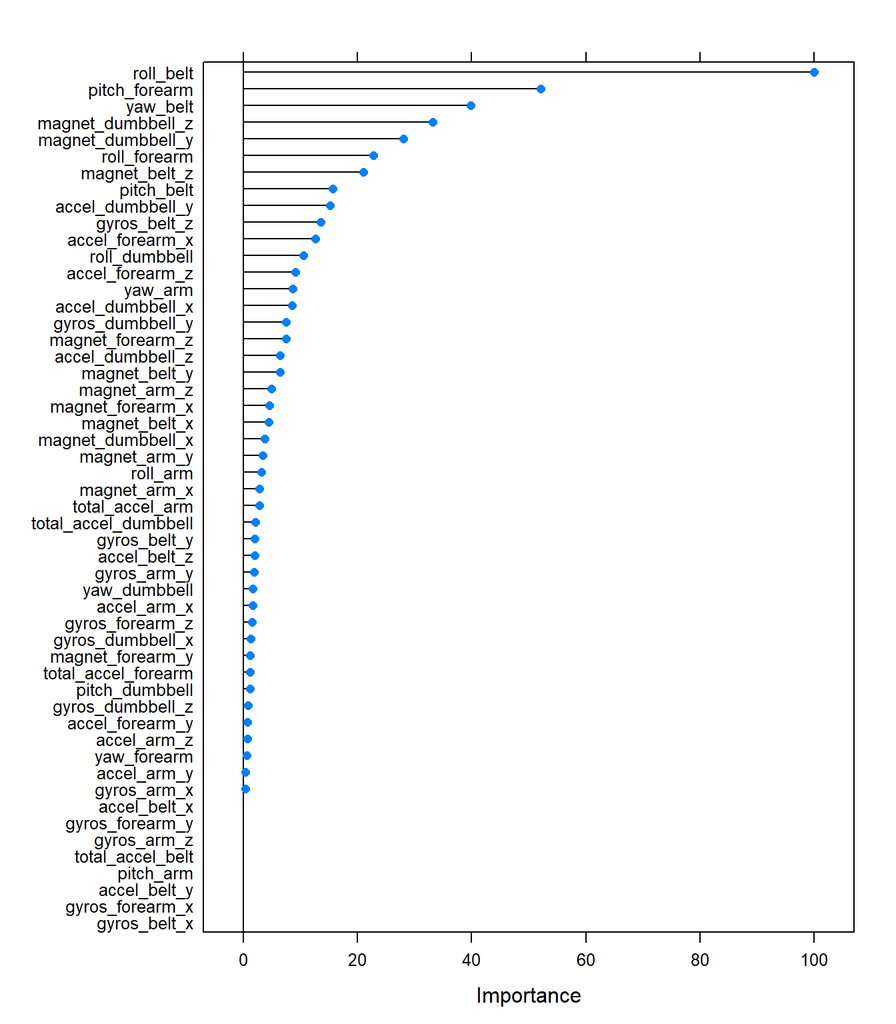

```r
plot(varImp(gbm.model))
```

Result: An accuracy of +/- 96% when max depth = 3 and boosting iterations = 150